# Exploratory Data Analysis of Meuse Dataset

## Introduction

The Meuse dataset contains spatial data on cadmium, copper, and zinc concentrations in soil samples collected from the Meuse River basin in the Netherlands. In this exploratory data analysis (EDA), we will investigate the distribution, relationships, and patterns within the dataset.

## Loading and Preparing Data

```r
# Load necessary libraries
library(sp)
library(ggplot2)
library(corrplot)

# Load the Meuse dataset
data(meuse)

# Display the first few rows of the dataset
head(meuse)
```

```
##        x      y cadmium copper lead zinc  elev       dist   om ffreq soil lime
## 1 181072 333611    11.7     85  299 1022 7.909 0.00135803 13.6     1    1    1
## 2 181025 333558     8.6     81  277 1141 6.983 0.01222430 14.0     1    1    1
## 3 181165 333537     6.5     68  199  640 7.800 0.10302900 13.0     1    1    1
## 4 181298 333484     2.6     81  116  257 7.655 0.19009400  8.0     1    2    0
## 5 181307 333330     2.8     48  117  269 7.480 0.27709000  8.7     1    2    0
## 6 181390 333260     3.0     61  137  281 7.791 0.36406700  7.8     1    2    0
##   landuse dist.m
## 1      Ah     50
## 2      Ah     30
## 3      Ah    150
## 4      Ga    270
## 5      Ah    380
## 6      Ga    470
```

## Overview of the Dataset

```r
# Display the structure of the dataset
str(meuse)
```

```
## 'data.frame':    155 obs. of  14 variables:
##  $ x      : num  181072 181025 181165 181298 181307 ...
##  $ y      : num  333611 333558 333537 333484 333330 ...
##  $ cadmium: num  11.7 8.6 6.5 2.6 2.8 3 3.2 2.8 2.4 1.6 ...
##  $ copper : num  85 81 68 81 48 61 31 29 37 24 ...
##  $ lead   : num  299 277 199 116 117 137 132 150 133 80 ...
##  $ zinc   : num  1022 1141 640 257 269 ...
##  $ elev   : num  7.91 6.98 7.8 7.66 7.48 ...
##  $ dist   : num  0.00136 0.01222 0.10303 0.19009 0.27709 ...
##  $ om     : num  13.6 14 13 8 8.7 7.8 9.2 9.5 10.6 6.3 ...
##  $ ffreq  : Factor w/ 3 levels "1","2","3": 1 1 1 1 1 1 1 1 1 1 ...
##  $ soil   : Factor w/ 3 levels "1","2","3": 1 1 1 2 2 2 2 1 1 2 ...
##  $ lime   : Factor w/ 2 levels "0","1": 2 2 2 1 1 1 1 1 1 1 ...
##  $ landuse: Factor w/ 15 levels "Aa","Ab","Ag",..: 4 4 4 11 4 11 4 2 2 15 ...
##  $ dist.m : num  50 30 150 270 380 470 240 120 240 420 ...
```

## Summary Statistics

```r
# Summary statistics of numeric variables
summary(meuse[, -c(1, 4)])
```

```
##        y             cadmium            lead            zinc
##  Min.   :329714   Min.   : 0.200   Min.   : 37.0   Min.   : 113.0
##  1st Qu.:330762   1st Qu.: 0.800   1st Qu.: 72.5   1st Qu.: 198.0
##  Median :331633   Median : 2.100   Median :123.0   Median : 326.0
##  Mean   :331635   Mean   : 3.246   Mean   :153.4   Mean   : 469.7
##  3rd Qu.:332463   3rd Qu.: 3.850   3rd Qu.:207.0   3rd Qu.: 674.5
##  Max.   :333611   Max.   :18.100   Max.   :654.0   Max.   :1839.0
##
##       elev             dist               om         ffreq  soil   lime
##  Min.   : 5.180   Min.   :0.00000   Min.   : 1.000   1:84   1:97   0:111
##  1st Qu.: 7.546   1st Qu.:0.07569   1st Qu.: 5.300   2:48   2:46   1: 44
##  Median : 8.180   Median :0.21184   Median : 6.900   3:23   3:12
##  Mean   : 8.165   Mean   :0.24002   Mean   : 7.478
##  3rd Qu.: 8.955   3rd Qu.:0.36407   3rd Qu.: 9.000
##  Max.   :10.520   Max.   :0.88039   Max.   :17.000
##                                     NA's   :2
##     landuse       dist.m
##  W      :50   Min.   :  10.0
##  Ah     :39   1st Qu.:  80.0
##  Am     :22   Median : 270.0
##  Fw     :10   Mean   : 290.3
##  Ab     : 8   3rd Qu.: 450.0
##  (Other):25   Max.   :1000.0
##  NA's   : 1
```

#Spatial Distribution of Variables

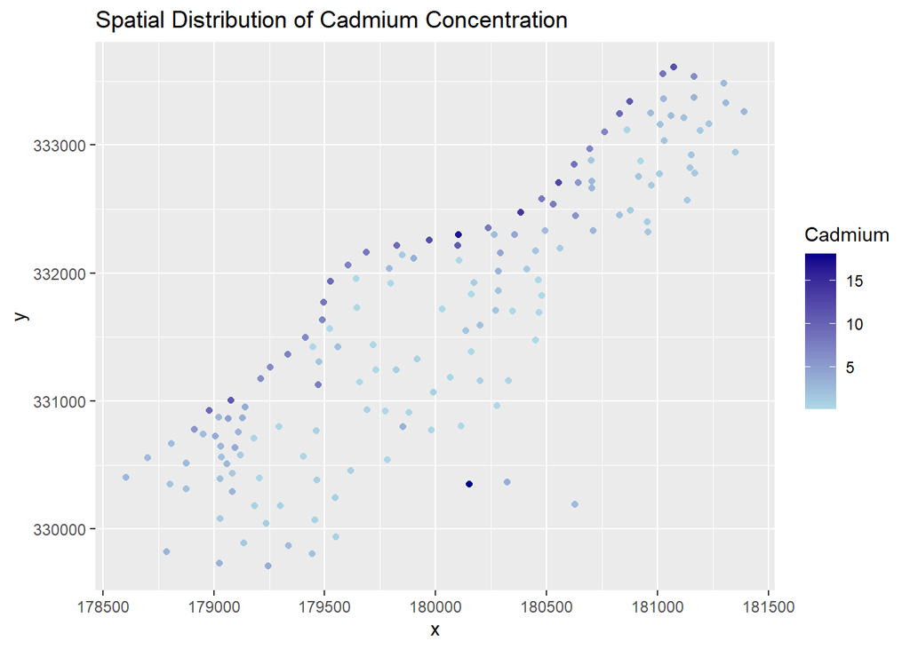

```r
# Load necessary libraries
library(ggplot2)
# Create spatial plot for cadmium concentration using ggplot2
ggplot(data = meuse, aes(x = x, y = y, color = cadmium)) +
  geom_point() +
  scale_color_gradient(name = "Cadmium", low = "lightblue", high = "darkblue") +
  labs(title = "Spatial Distribution of Cadmium Concentration")
```

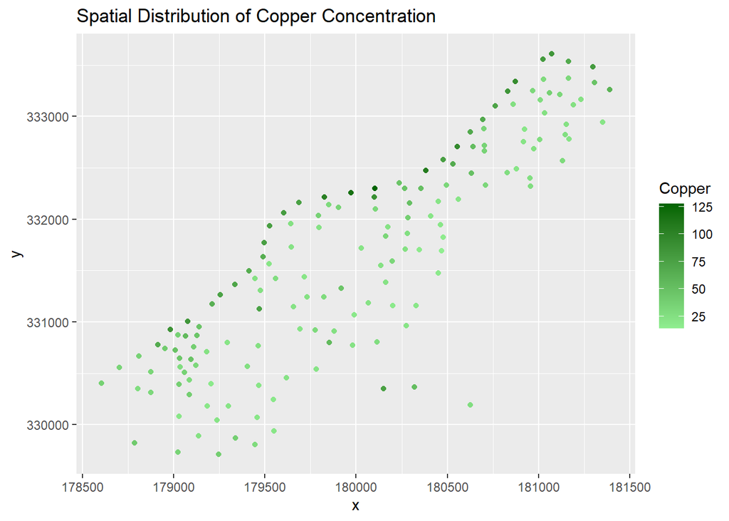

```r
# Create spatial plot for copper concentration using ggplot2
ggplot(data = meuse, aes(x = x, y = y, color = copper)) +
  geom_point() +
  scale_color_gradient(name = "Copper", low = "lightgreen", high = "darkgreen") +
  labs(title = "Spatial Distribution of Copper Concentration")
```

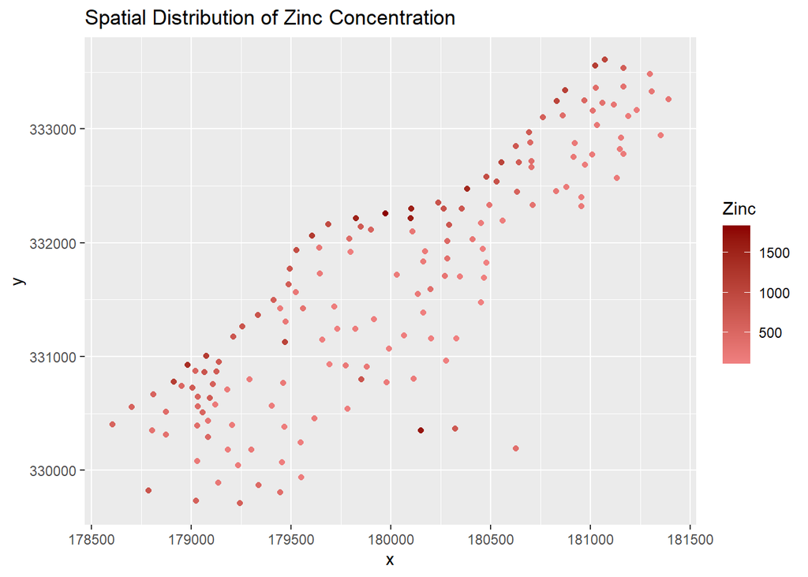

```r
# Create spatial plot for zinc concentration using ggplot2
ggplot(data = meuse, aes(x = x, y = y, color = zinc)) +
  geom_point() +
  scale_color_gradient(name = "Zinc", low = "lightcoral", high = "darkred") +
  labs(title = "Spatial Distribution of Zinc Concentration")
```

These plots visualize the spatial distribution of cadmium, copper, and zinc concentrations across the Meuse River basin.

## Scatterplot Matrix

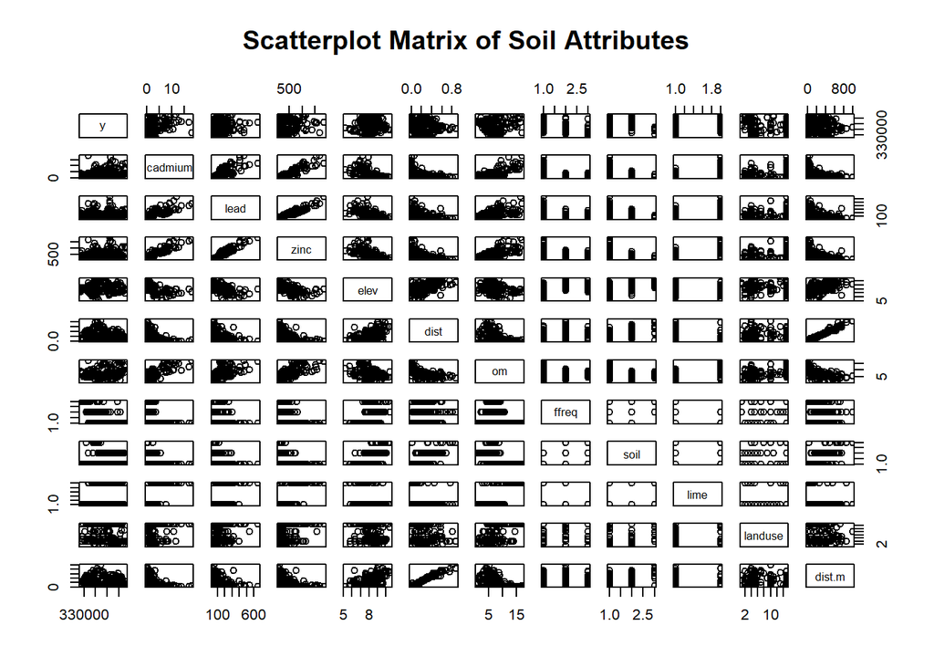

```r
# Create scatterplot matrix
pairs(meuse[, -c(1, 4)], main = "Scatterplot Matrix of Soil Attributes")
```

This scatterplot matrix illustrates the relationships between different soil attributes, allowing for visual inspection of potential patterns or trends.